# Contact Experiment Data Analysis

```r
shapiro_test(df2_clean$AverageInterpenetration) # YEAH! Normal Distribution ladies and gentlemen :)
```

| variable | statistic | p.value |
| --- | --- | --- |
| df2_clean$AverageInterpenetration | 0.9894894 | 0.2125809 |

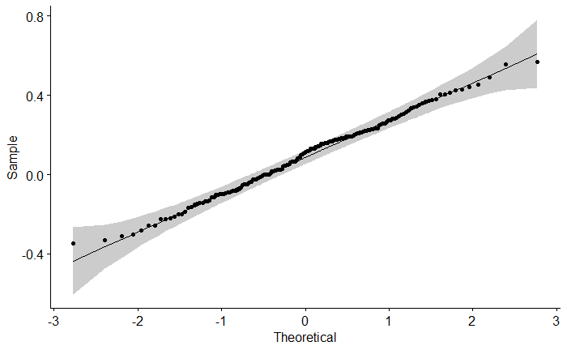

```r
ggqqplot(df2_clean$MaxInterpenetration)
```

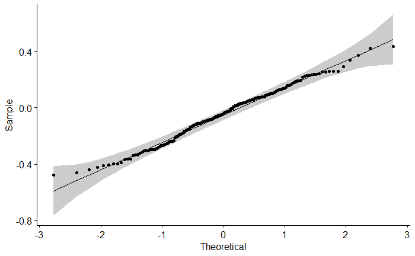

```r
ggqqplot(df2_clean$AverageInterpenetration) #qqplots are still good.
```

```r
df2_clean %>%
  group_by(InterpenetrationFeedback, FullyShaded) %>%
  shapiro_test(MaxInterpenetration)
```

| InterpenetrationFeedback | FullyShaded | variable | statistic | p |
| --- | --- | --- | --- | --- |
| Both | FALSE | MaxInterpenetration | 0.9832508 | 0.95334896 |
| Both | TRUE | MaxInterpenetration | 0.9819024 | 0.93584293 |
| Electrotactile | FALSE | MaxInterpenetration | 0.9232895 | 0.10097834 |
| Electrotactile | TRUE | MaxInterpenetration | 0.9697258 | 0.70471449 |
| NoFeedback | FALSE | MaxInterpenetration | 0.9700971 | 0.71329321 |
| NoFeedback | TRUE | MaxInterpenetration | 0.9461519 | 0.26444893 |
| Visual | FALSE | MaxInterpenetration | 0.9252954 | 0.08657014 |
| Visual | TRUE | MaxInterpenetration | 0.9798436 | 0.91353107 |

```r
df2_clean %>%
  group_by(InterpenetrationFeedback, FullyShaded) %>%
  shapiro_test(AverageInterpenetration)
```

| InterpenetrationFeedback | FullyShaded | variable | statistic | p |
| --- | --- | --- | --- | --- |
| Both | FALSE | AverageInterpenetration | 0.9748404 | 0.8025696 |
| Both | TRUE | AverageInterpenetration | 0.9850372 | 0.9717764 |
| Electrotactile | FALSE | AverageInterpenetration | 0.9470708 | 0.2995164 |
| Electrotactile | TRUE | AverageInterpenetration | 0.9785742 | 0.8923237 |
| NoFeedback | FALSE | AverageInterpenetration | 0.9354463 | 0.1592924 |
| NoFeedback | TRUE | AverageInterpenetration | 0.9615241 | 0.5206929 |
| Visual | FALSE | AverageInterpenetration | 0.9407188 | 0.1862110 |
| Visual | TRUE | AverageInterpenetration | 0.9591520 | 0.4723292 |

```r
# No Violations . We are ready for Two Way Repeated Measures ANOVA


# However
#It seems that many of the outliers (> 1.5 coeff) were also extremes (> 3 coeff)
# While all the outliers and the extremes derive from the IDs : 9 , 17 , and 20
```

#!diagnostics suppress=<Extreme1, Extreme2> Another Solution for solving the normality violation

```r
#Another more extreme solution for positive skewness
# For extreme cases, we can also try also to divide 1 by our values (Re assign )

# df_clean$MaxInterpenetration <- 1/df_clean$MaxInterpenetration

# df_clean$AverageInterpenetration <- 1/df_clean$AverageInterpenetration
```

let’s check the plots of the means to see what happens in our cleaned data.

```r
# We are going to prefer the one where we excluded only the extreme values
# so df2_clean will be the df that we will use

# The first two blocks comparing IVs effect on DV
p1 <- ggstatsplot::ggbetweenstats(
  data = df2_clean,
  x = "InterpenetrationFeedback", #Indepedent Variable
  y = "MaxInterpenetration", # Depedent Variable
  grouping.var = "FullyShaded", # 2nd IV
  type = "p", # parametric test i.e., p values
  pairwise.comparisons = TRUE, #compute pairwise comparisons
  pairwise.display = "significant",
  p.adjust.method = "bonferroni", # correction of p-value
  effsize.type = "unbiased", # Calculates the Hedge's g for t tests and the partial Omega for ANOVA
  xlab = "Type of Feedback", #label of X axis
  ylab = "Maximum Interpenetration", #label of y axis
  var.equal = TRUE, #Assuming Equal variances
  mean.ci = TRUE, #display the confidence interval of the mean
  notch = TRUE, #Compare the medians i.e., IQR with 95% confidence interval
  paired = TRUE #indicating that we have a within subject design
  )

p2 <- ggstatsplot::ggbetweenstats(
  data = df2_clean,
  x = "InterpenetrationFeedback",
  y = "AverageInterpenetration",
  grouping.var = "FullyShaded",
  type = "p",
  pairwise.comparisons = TRUE,
  pairwise.display = "significant",
  p.adjust.method = "bonferroni",
  effsize.type = "unbiased",
  xlab = "Type of Feedback",
  ylab = "Average Interpenetration",
  var.equal = TRUE,
  mean.ci = TRUE,
  notch = TRUE,
  paired = TRUE
)


# Replicating the above but this time we look on the effect of the type of feedback on the DVs when the shaded is true and when it is false.
p3 <- ggstatsplot::grouped_ggbetweenstats(
  data = df2_clean,
  x = "InterpenetrationFeedback",
  y = "MaxInterpenetration",
  grouping.var = "FullyShaded",
  type = "p",
  pairwise.comparisons = TRUE,
  pairwise.display = "significant",
  p.adjust.method = "bonferroni",
  effsize.type = "unbiased",
  xlab = "Type of Feedback",
  ylab = "Maximum Interpenetration",
  sub.text = "Explicit Visual Representation" ,
  var.equal = TRUE,
  mean.ci = TRUE,
  notch = TRUE,
  paired = TRUE
  )
```

```
notch went outside hinges. Try setting notch=FALSE.
```

```r
p4 <- ggstatsplot::grouped_ggbetweenstats(
  data = df2_clean,
  x = "InterpenetrationFeedback",
  y = "AverageInterpenetration",
  grouping.var = "FullyShaded",
  type = "p",
  pairwise.comparisons = TRUE,
  pairwise.display = "significant",
  p.adjust.method = "bonferroni",
  effsize.type = "unbiased",
  xlab = "Type of Feedback",
  ylab = "Average Interpenetration",
  var.equal = TRUE,
  mean.ci = TRUE,
  notch = TRUE,
  paired = TRUE
)
```

```
notch went outside hinges. Try setting notch=FALSE.
notch went outside hinges. Try setting notch=FALSE.
notch went outside hinges. Try setting notch=FALSE.
```

```r
# Lets check the effect of shaded condition on DVs
p5 <- ggstatsplot:: ggbetweenstats(
  data = df2_clean,
  x = "FullyShaded",
  y = "MaxInterpenetration",
  grouping.var = "InterpenetrationFeedback",
  type = "p",
  pairwise.comparisons = TRUE,
  pairwise.display = "significant",
  p.adjust.method = "bonferroni",
  effsize.type = "unbiased",
  xlab = "Target's Visual Representation",
  ylab = "Maximum Interpenetration",
  sub.text = "Explicit Visual Representation" ,
  var.equal = TRUE,
  mean.ci = TRUE,
  notch = TRUE,
  paired = TRUE
  )

p6 <- ggstatsplot::ggbetweenstats(
  data = df2_clean,
  x = "FullyShaded",
  y = "AverageInterpenetration",
  grouping.var = "InterpenetrationFeedback",
  type = "p",
  pairwise.comparisons = TRUE,
  pairwise.display = "significant",
  p.adjust.method = "bonferroni",
  effsize.type = "unbiased",
  xlab = "Target's Visual Representation",
  ylab = "Average Interpenetration",
  var.equal = TRUE,
  mean.ci = TRUE,
  notch = TRUE,
  paired = TRUE
)

p7 <- ggstatsplot::grouped_ggbetweenstats(
  data = df2_clean,
  x = "FullyShaded",
  y = "MaxInterpenetration",
  grouping.var = "InterpenetrationFeedback",
  type = "p",
  pairwise.comparisons = TRUE,
  pairwise.display = "significant",
  p.adjust.method = "bonferroni",
  effsize.type = "unbiased",
  xlab = "Target's Visual Representation",
  ylab = "Maximum Interpenetration",
  sub.text = "Explicit Visual Representation" ,
  var.equal = TRUE,
  mean.ci = TRUE,
  notch = TRUE,
  paired = TRUE
  )
```

```
notch went outside hinges. Try setting notch=FALSE.
```

```r
p8 <- ggstatsplot::grouped_ggbetweenstats(
  data = df2_clean,
  x = "FullyShaded",
  y = "AverageInterpenetration",
  grouping.var = "InterpenetrationFeedback",
  type = "p",
  pairwise.comparisons = TRUE,
  pairwise.display = "significant",
  p.adjust.method = "bonferroni",
  effsize.type = "unbiased",
  xlab = "Target's Visual Representation",
  ylab = "Average Interpenetration",
  var.equal = TRUE,
  mean.ci = TRUE,
  notch = TRUE,
  paired = TRUE
)
```

```
notch went outside hinges. Try setting notch=FALSE.
notch went outside hinges. Try setting notch=FALSE.
notch went outside hinges. Try setting notch=FALSE.
```

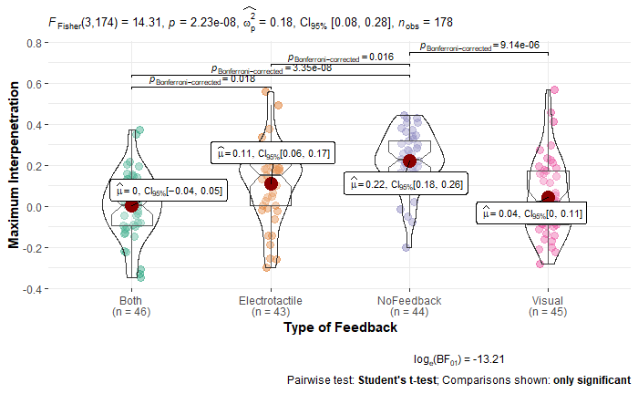

```r
p1
```

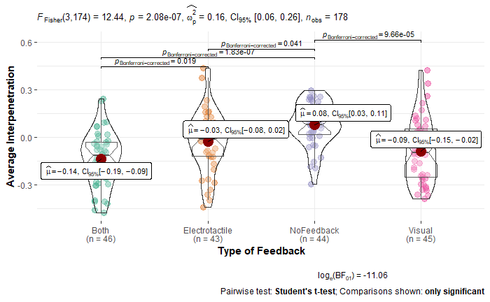

```r
p2
```

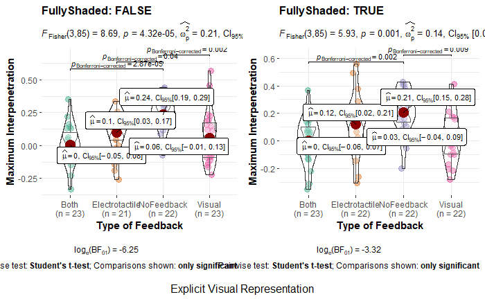

```r
p3
```

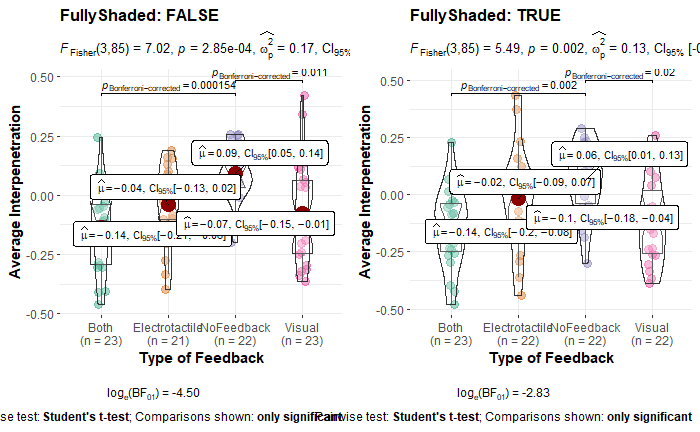

```r
p4
```

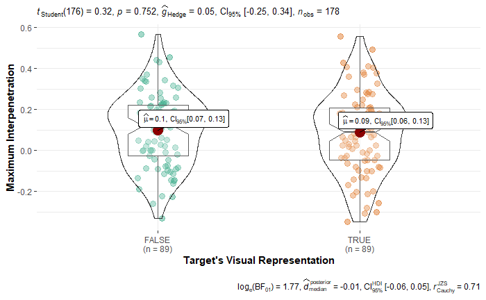

```r
p5
```

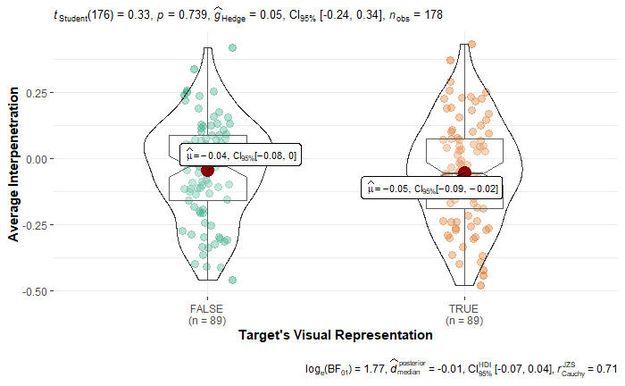

```r
p6
```

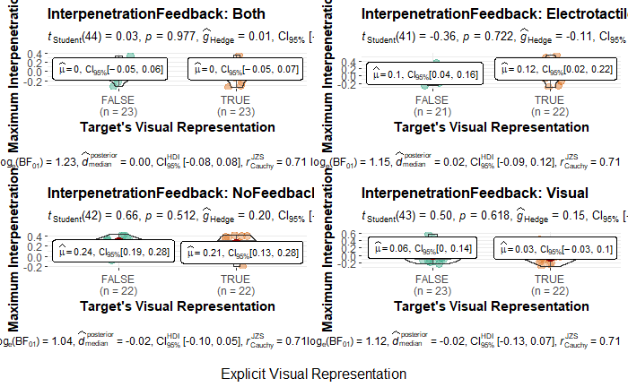

```r
p7
```

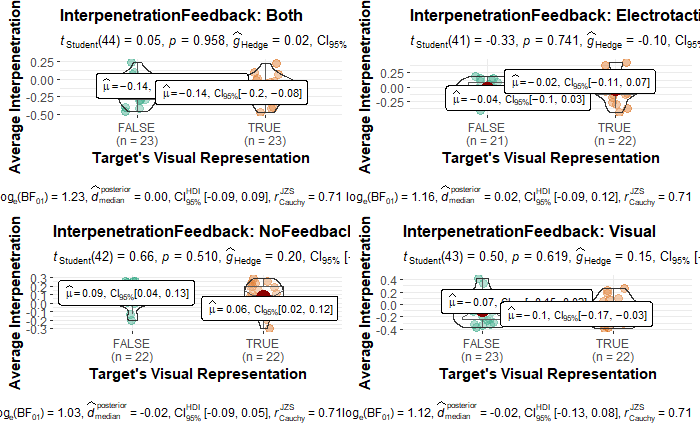

```r
p8
```

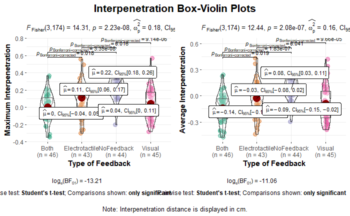

```r
plist <- list(p1,p2)
plist2 <- list(p3,p4)
plist3 <- list(p5,p6)
plist4 <- list(p7,p8)

combine_plots(
  plotlist = plist,
  title.text = "Interpenetration Box-Violin Plots",
  caption.text = "Note: Interpenetration distance is displayed in cm.",
  title.color = "black",
  caption.color = "black")
```

[figure not shown]

```r
combine_plots(
  plotlist = plist2,
  title.text = "Interpenetration Box-Violin Plots",
  caption.text = "Note: Interpenetration distance is displayed in cm.",
  title.color = "black",
  caption.color = "black")
```

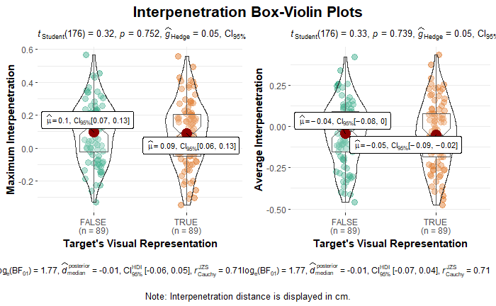

```r
combine_plots(
  plotlist = plist3,
  title.text = "Interpenetration Box-Violin Plots",
  caption.text = "Note: Interpenetration distance is displayed in cm.",
  title.color = "black",
  caption.color = "black")
```

[figure not shown]

```r
combine_plots(
  plotlist = plist4,
  title.text = "Interpenetration Box-Violin Plots",
  caption.text = "Note: Interpenetration distance is displayed in cm.",
  title.color = "black",
  caption.color = "black")
```

So based on the above plots we can see that ############################################### For the maximum interpenetration (plot 1):

Reference for interpreting Omega Squared Small effect: ω2 = 0.01; Medium effect: ω2 = 0.06; Large effect: ω2 = 0.14.

For averaged interpenentration (plot2):

Similar to the results for the maximum interpenetration

For the relationship between the shade condition and the type of feedback on

maximum interpenetration (plot3) & averaged interpenetration (plot4):

We can see that the results are similar to the plot1 when the shaded condition is false (i.e., when there is not an explicit visual representation of the target object).

Hence, we can theorize that an implicit visual representation of the target (i.e., non-fully shaded) increases the importance of the electrotactile feedback on the performance aspects. This also postulates that when the visual information is insufficient or ambiguous, then the electrotactile feedback complements the sensory information which facilitates visuospatial perception.

For the shaded condition alone, we can see that it doesn’t have an effect on performance (plot 5 & 6) regardless of the type of feedback (plot 7 & 8)

To Move on

Let’s check the Two Way Repeated Measures ANOVA now #!diagnostics suppress=<Extreme1, Extreme2>

```r
RM2W_Max <- anova_test(
  data = df2_clean, dv = MaxInterpenetration, wid = ID,
  formula = MaxInterpenetration ~ InterpenetrationFeedback + FullyShaded + InterpenetrationFeedback*FullyShaded + (1|ID),
  within = c(InterpenetrationFeedback, FullyShaded)
  )
```

```
Coefficient covariances computed by hccm()
Note: model has aliased coefficients
      sums of squares computed by model comparison
```

```r
 get_anova_table(RM2W_Max)
```

```
ANOVA Table (type II tests)

                                Effect DFn DFd      F        p p<.05      ges
1             InterpenetrationFeedback   3 170 14.054 3.16e-08     * 0.199000
2                          FullyShaded   1 170  0.143 7.06e-01       0.000841
3                               1 | ID   0 170     NA       NA  <NA>       NA
4 InterpenetrationFeedback:FullyShaded   3 170  0.211 8.89e-01       0.004000
```

```r
RM2W_Av <- anova_test(
  data = df2_clean, dv = AverageInterpenetration, wid = ID,
  formula = AverageInterpenetration ~ InterpenetrationFeedback + FullyShaded + InterpenetrationFeedback*FullyShaded + (1|ID),
  )
```

```
Coefficient covariances computed by hccm()
Note: model has aliased coefficients
      sums of squares computed by model comparison
```

```r
 get_anova_table(RM2W_Av)
```

```
ANOVA Table (type II tests)

                                Effect DFn DFd      F        p p<.05      ges
1             InterpenetrationFeedback   3 170 12.208 2.84e-07     * 0.177000
2                          FullyShaded   1 170  0.151 6.98e-01       0.000889
3                               1 | ID   0 170     NA       NA  <NA>       NA
4 InterpenetrationFeedback:FullyShaded   3 170  0.189 9.04e-01       0.003000
```

There is neither a significant effect of the fully shaded on the DV, nor a significant interrelationship effect between fully shaded and interpenetration feedback. On the other hand Interpenetration feedback has a sign effect on DVs.

So, lets go for an ONE Way Repeated Measures ANOVA now

```r
RM1W_Max <- anova_test(
  data = df2_clean, dv = MaxInterpenetration, wid = ID,
  formula = MaxInterpenetration ~ InterpenetrationFeedback + (1|ID),
  )
```

```
Coefficient covariances computed by hccm()
Note: model has aliased coefficients
      sums of squares computed by model comparison
```

```r
 get_anova_table(RM1W_Max )
```

```
ANOVA Table (type II tests)

                    Effect DFn DFd      F        p p<.05   ges
1 InterpenetrationFeedback   3 174 14.312 2.23e-08     * 0.198
2                   1 | ID   0 174     NA       NA  <NA>    NA
```

```r
RM1W_Av <- anova_test(
  data = df2_clean, dv = AverageInterpenetration, wid = ID,
  formula = AverageInterpenetration ~ InterpenetrationFeedback + (1|ID),
  )
```

```
Coefficient covariances computed by hccm()
Note: model has aliased coefficients
      sums of squares computed by model comparison
```

```r
 get_anova_table(RM1W_Av)
```

```
ANOVA Table (type II tests)

                    Effect DFn DFd      F        p p<.05   ges
1 InterpenetrationFeedback   3 174 12.436 2.08e-07     * 0.177
2                   1 | ID   0 174     NA       NA  <NA>    NA
```

OK, there is significant effect of the interpenetration feedback on both DVs

#!diagnostics suppress=<Extreme1, Extreme2> Let’s go for the post hoc tests

```r
pwMax <- pairwise.t.test(df2_clean$MaxInterpenetration, df2_clean$InterpenetrationFeedback, p.adjust.method = "bonferroni",
        paired = FALSE, alternative = "two.sided")


pwAv <- pairwise.t.test(df2_clean$AverageInterpenetration, df2_clean$InterpenetrationFeedback, p.adjust.method = "bonferroni",
        paired = FALSE, alternative = "two.sided")


#require(effectsize)
#?hedges_g()

#effectsize::hedges_g("AverageInterpenetration", "InterpenetrationFeedback", data = df2_clean, correction = TRUE, paired = TRUE)


pwMax
```

```
    Pairwise comparisons using t tests with pooled SD

data:  df2_clean$MaxInterpenetration and df2_clean$InterpenetrationFeedback

               Both    Electrotactile NoFeedback
Electrotactile 0.018   -              -
NoFeedback     3.4e-08 0.016          -
Visual         1.000   0.367          9.1e-06

P value adjustment method: bonferroni
```

```r
pwAv
```

```
    Pairwise comparisons using t tests with pooled SD

data:  df2_clean$AverageInterpenetration and df2_clean$InterpenetrationFeedback

               Both    Electrotactile NoFeedback
Electrotactile 0.019   -              -
NoFeedback     1.8e-07 0.041          -
Visual         1.000   0.595          9.7e-05

P value adjustment method: bonferroni
```

We have significant results but the paired = TRUE option wasn’t possible because the levels of the IV do NOT have the same length (unbalanced data)

If you run the ANOVA above then you will see that we get some errors indicating that don not have balanced data (i.e., unbalanced data)

CORRECTION!!!!! ################################ THE PROBLEM WAS IRRELEVANT TO THE DATA ################################################# IT WAS a R Studio Bug. Though, the data are indeed unbalanced!!!!

######################## So we may go or not for the below ########################

Possible solutions for unbalanced data:

1. Using the ezMixed function from the ez package, which wraps lmer and produces likelihood ratios (a superior metric of evidence)
2. Deleting the IDs which produced the extreme values. However, we will reduce the sample size to N = 21. Also, the observations will be 21 (the participants) * 8 Conditions (i.e., 4 types of feedback * 2 Shaded conditions) = 168 observations
3. To try and catch the extreme values before averaging the data! By doing that, we may be able to keep the N = 24. Thanks Ferran :)

#!diagnostics suppress=<Extreme1, Extreme2> So, we will start from solution 3, because it is the best case scenario

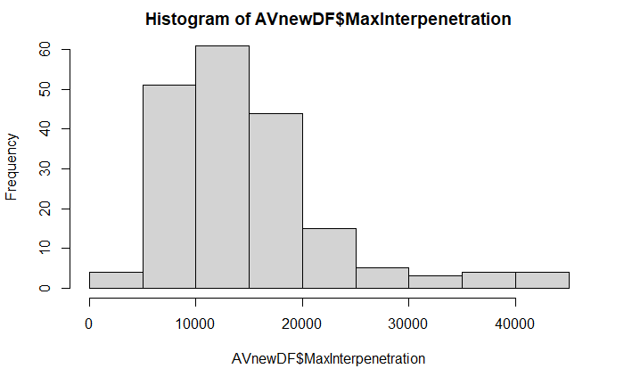

```r
data$Extreme1 <- is_extreme(data$MaxInterpenetration)

data$Extreme2 <- is_extreme(data$AverageInterpenetration)

data$Extreme1[data$Extreme1 == TRUE]  <- NA
data$Extreme2[data$Extreme2 == TRUE]  <- NA

data_clean <- na.omit(data)

newDF <- data_clean
#newDF <- select(data_clean, -"Trial", -"TrialInBlock", -"NrOfAdjustments" ,
#                 -"Completed" , -"Attempts" , -"Skipped", -"Extreme1", -"Extreme2")

AVnewDF <- aggregate(. ~ ID + Age + Gender + InterpenetrationFeedback + FullyShaded, newDF, mean)

AVnewDF$MaxInterpenetration <- AVnewDF$MaxInterpenetration * 100
AVnewDF$MaxInterpenetration <- AVnewDF$MaxInterpenetration * 100
AVnewDF$MaxInterpenetration <- AVnewDF$MaxInterpenetration * 100

hist(AVnewDF$MaxInterpenetration)
```

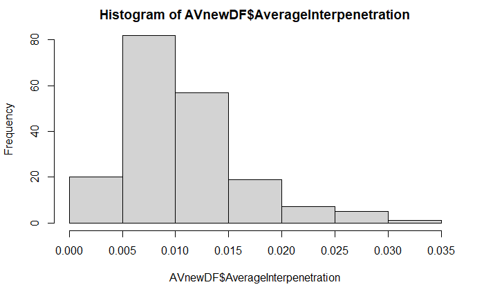

```r
hist(AVnewDF$AverageInterpenetration)
```

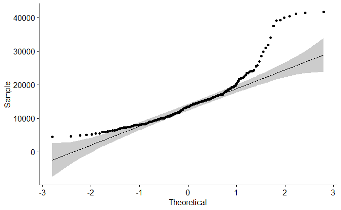

```r
ggqqplot(AVnewDF$MaxInterpenetration)
```

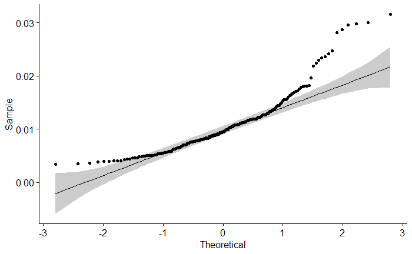

```r
ggqqplot(AVnewDF$AverageInterpenetration)
```

```r
shapiro_test(AVnewDF$MaxInterpenetration)
```

| variable | statistic | p.value |
| --- | --- | --- |
| AVnewDF$MaxInterpenetration | 0.8534891 | 1.388171e-12 |

```r
shapiro_test(AVnewDF$AverageInterpenetration)
```

| variable | statistic | p.value |
| --- | --- | --- |
| AVnewDF$AverageInterpenetration | 0.8716902 | 1.161711e-11 |

```r
AVnewDF %>%
  group_by(InterpenetrationFeedback, FullyShaded) %>%
  shapiro_test(MaxInterpenetration)
```

| InterpenetrationFeedback | FullyShaded | variable | statistic | p |
| --- | --- | --- | --- | --- |
| Both | FALSE | MaxInterpenetration | 0.6772161 | 5.108148e-06 |
| Both | TRUE | MaxInterpenetration | 0.7096765 | 1.355719e-05 |
| Electrotactile | FALSE | MaxInterpenetration | 0.7429277 | 3.933390e-05 |
| Electrotactile | TRUE | MaxInterpenetration | 0.8875739 | 1.184652e-02 |
| NoFeedback | FALSE | MaxInterpenetration | 0.9580730 | 4.255826e-01 |
| NoFeedback | TRUE | MaxInterpenetration | 0.8753741 | 6.715610e-03 |
| Visual | FALSE | MaxInterpenetration | 0.7625419 | 7.636218e-05 |
| Visual | TRUE | MaxInterpenetration | 0.8850715 | 1.052862e-02 |

```r
AVnewDF %>%
  group_by(InterpenetrationFeedback, FullyShaded) %>%
  shapiro_test(AverageInterpenetration)
```

| InterpenetrationFeedback | FullyShaded | variable | statistic | p |
| --- | --- | --- | --- | --- |
| Both | FALSE | AverageInterpenetration | 0.7428945 | 3.929067e-05 |
| Both | TRUE | AverageInterpenetration | 0.7212665 | 1.949605e-05 |
| Electrotactile | FALSE | AverageInterpenetration | 0.7915473 | 2.149920e-04 |
| Electrotactile | TRUE | AverageInterpenetration | 0.8773690 | 7.359422e-03 |
| NoFeedback | FALSE | AverageInterpenetration | 0.9421476 | 1.998001e-01 |
| NoFeedback | TRUE | AverageInterpenetration | 0.9079121 | 3.178452e-02 |
| Visual | FALSE | AverageInterpenetration | 0.7928027 | 2.251971e-04 |
| Visual | TRUE | AverageInterpenetration | 0.8821107 | 9.166586e-03 |